# Lab 04 - Data Visualization

```r
library(data.table)
library(leaflet)
library(tidyverse)
```

# Deliverables

- Answer questions below, knit to html and submit to Quercus.

# Learning Goals

- Read in and prepare the meteorological dataset
- Create several graphs with different `geoms()` in `ggplot2`
- Create a facet graph
- Conduct some customizations of the graphs
- Create a more detailed map using `leaflet()`

# Lab Description

We will again work with the meteorological data from last week.

**The objective of the lab is to examine the association between weekly average dew point temperature and wind speed in four regions of the US and by elevation.**

# Steps

### 1. Read in the data

First download and then read in with data.table:fread()

```r
download.file(
  "https://raw.githubusercontent.com/JSC370/JSC370-2025/main/data/met/met_all.gz",
  destfile = "met_all.gz",
  method   = "curl",
  timeout  = 60
  )

met <- data.table::fread("met_all.gz")
```

### 2. Prepare the data.

- Based on last week’s lab, remove suspect/incorrect observations.
- Generate a date variable.
- Using the `data.table::week` function, keep the observations of the first week of the month.
- Compute the mean by station of the variables `temp`, `rh`, `wind.sp`, `vis.dist`, `dew.point`, `lat`,`lon`, and `elev`.
- Create a categorical variable for elevation (break point at 252 m)
- Create a region variable for NW, SW, NE, SE based on lon = -98.00 and lat = 39.71 degrees

```r
met <- met[temp > -17][elev == 9999, elev := NA]

# Generate a date variable
# Using the `data.table::week` function, keep the observations of the first week of the month.

met[, week := week(as.Date(paste(year, month, day, sep = "-")))]
met_first_week <- met[week == min(week, na.rm = TRUE)]

# Compute the mean by station of the variables `temp`, `rh`, `wind.sp`, `vis.dist`, `dew.point`, `lat`,`lon`, and `elev`.
met_avg <- met_first_week[, .(
  temp = mean(temp, na.rm=TRUE),
  rh = mean(rh, na.rm=TRUE),
  wind.sp = mean(wind.sp, na.rm=TRUE),
  vis.dist = mean(vis.dist, na.rm=TRUE),
  dew.point = mean(dew.point, na.rm=TRUE),
  elev = mean(elev, na.rm=TRUE),
  lat = mean(lat),
  lon = mean(lon)
), by="USAFID"]
```

```r
# Create a categorical variable for elevation (break point at 252 m)
met_avg[, elev_cat := ifelse(elev > 252, "high", "low")]

# Create a region variable for NW, SW, NE, SE based on lon = -98.00 and lat = 39.71 degrees
# lon > -98, lat > 39 NE
# lon > -98, lat <= 39 SE
# lon <= -98, lat > 39 NW
# lon <= -98, lat <= 39 SQ
met_avg[, region := ifelse(lon > 98 & lat > 39.71, "North East",
                           ifelse(lon > 98, "South East",
                                  ifelse(lat > 39.71, "North West", "South West")))]

# lat > 39 North South
# lon > -98 east west

met_avg[, region:= paste(ifelse(lat > 39.71, "North", "South"),
                         ifelse(lon > -98, "East", "West"))]

table(met_avg$region, useNA = "always")
```

```
##
## North East North West South East South West       <NA>
##        484        146        649        296          0
```

### 3. Use `geom_violin` to examine the wind speed and dew point temperature by region.

You saw how to use `geom_boxplot` in class. Try using `geom_violin` instead (take a look at the help). Hint: You will need to set the `x` aesthetic to 1.

- Use facets.
- Make sure to deal with `NA` category.
- Describe what you observe in the graph.

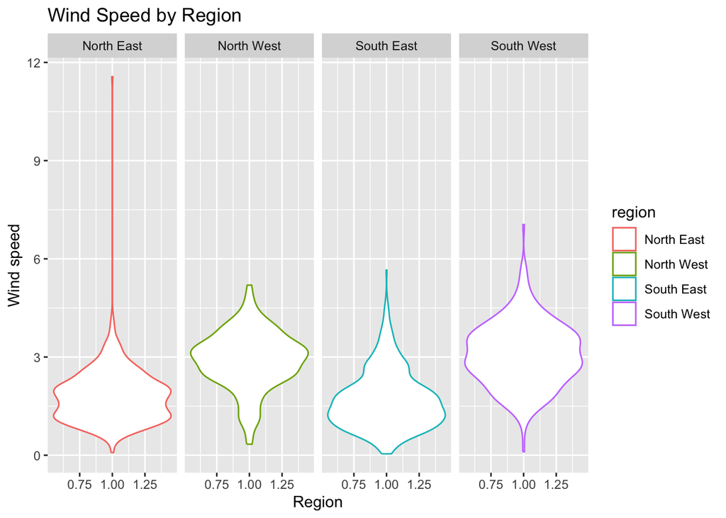

```r
met_avg |>
  filter(!is.na(region), !is.na(wind.sp)) |>
  ggplot() +
  geom_violin(mapping = aes(x = 1, y=wind.sp, color=region)) +
  facet_wrap(~region, nrow=1) +
  labs(
   x = "Region",
   y = "Wind speed",
   title="Wind Speed by Region"
  )
```

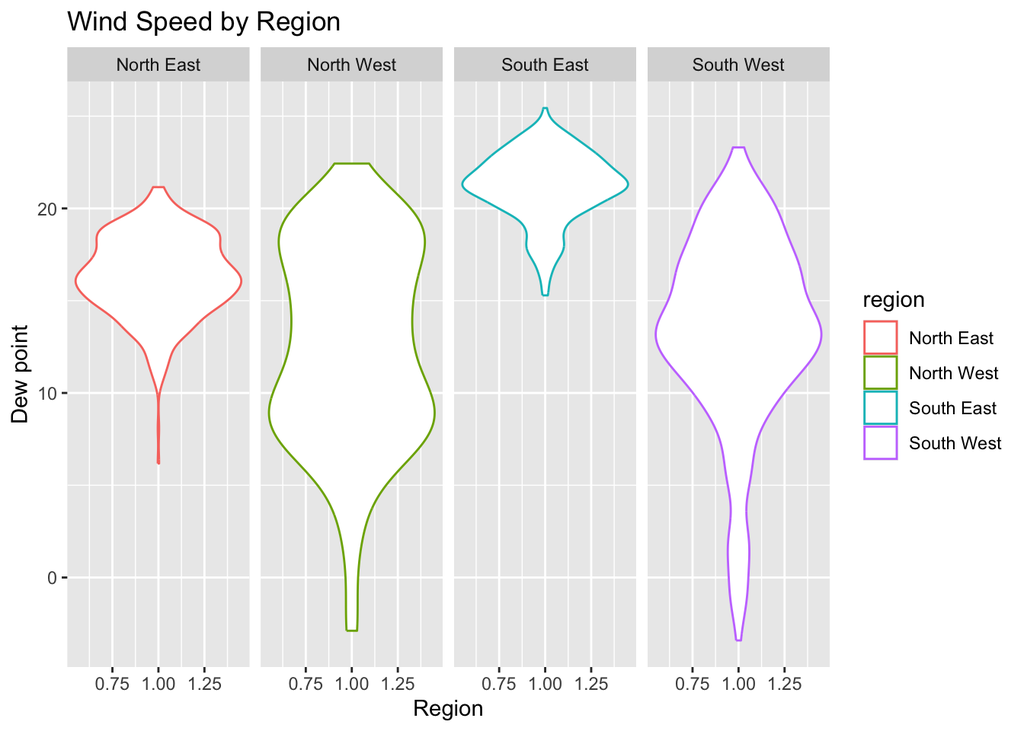

```r
met_avg |>
  filter(!is.na(region), !is.na(dew.point)) |>
  ggplot() +
  geom_violin(mapping = aes(x = 1, y=dew.point, color=region)) +
  facet_wrap(~region, nrow=1) +
  labs(
   x = "Region",
   y = "Dew point",
   title="Wind Speed by Region"
  )
```

### 4. Use `geom_jitter` with `stat_smooth` to examine the association between dew point temperature and wind speed by region.

- Color points by region
- Make sure to deal with `NA` category
- Fit a linear regression line by region
- **Describe** what you observe in the graph

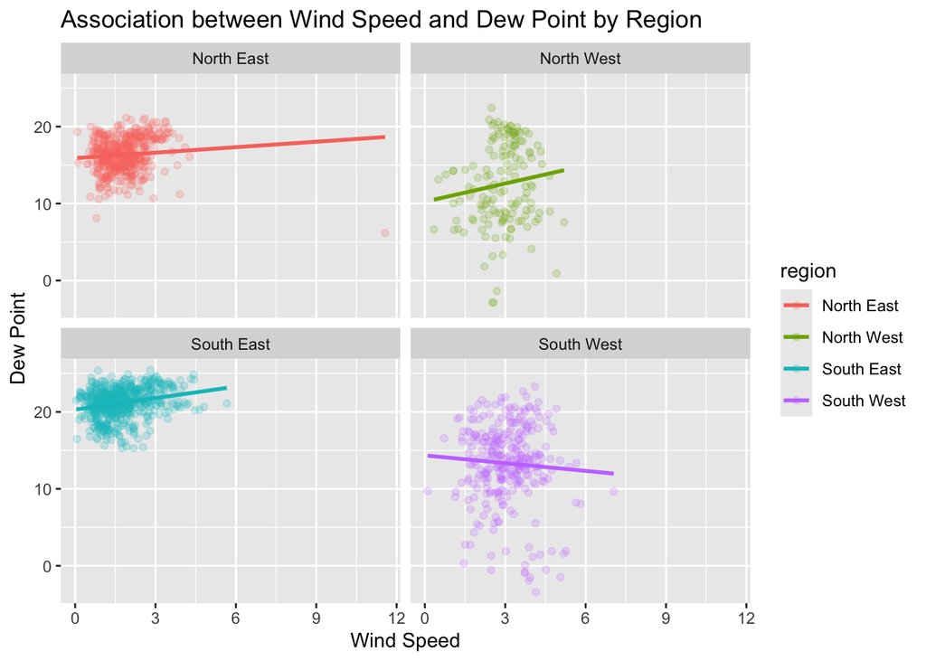

```r
met_avg |>
  filter(!is.na(region), !is.na(dew.point), !is.na(wind.sp)) |>
  ggplot(mapping=aes(x = wind.sp, y=dew.point, color=region)) +
  stat_smooth(method = lm, formula = y ~ x, se=FALSE) +
  geom_jitter(alpha = .2) +
  facet_wrap(~region, nrow=2) +
  labs(
   x = "Wind Speed",
   y = "Dew Point",
   title="Association between Wind Speed and Dew Point by Region"
  )
```

### 5. Use `geom_bar` to create barplots of the weather stations by elevation category coloured by region.

- Bars by elevation category using `position = "dodge"`
- Change colors from the default. Color by region using `scale_fill_brewer` see [this](http://rstudio-pubs-static.s3.amazonaws.com/5312_98fc1aba2d5740dd849a5ab797cc2c8d.html)
- Create nice labels on axes and add a title
- Try a different theme
- Describe what you observe in the graph
- Make sure to deal with `NA`

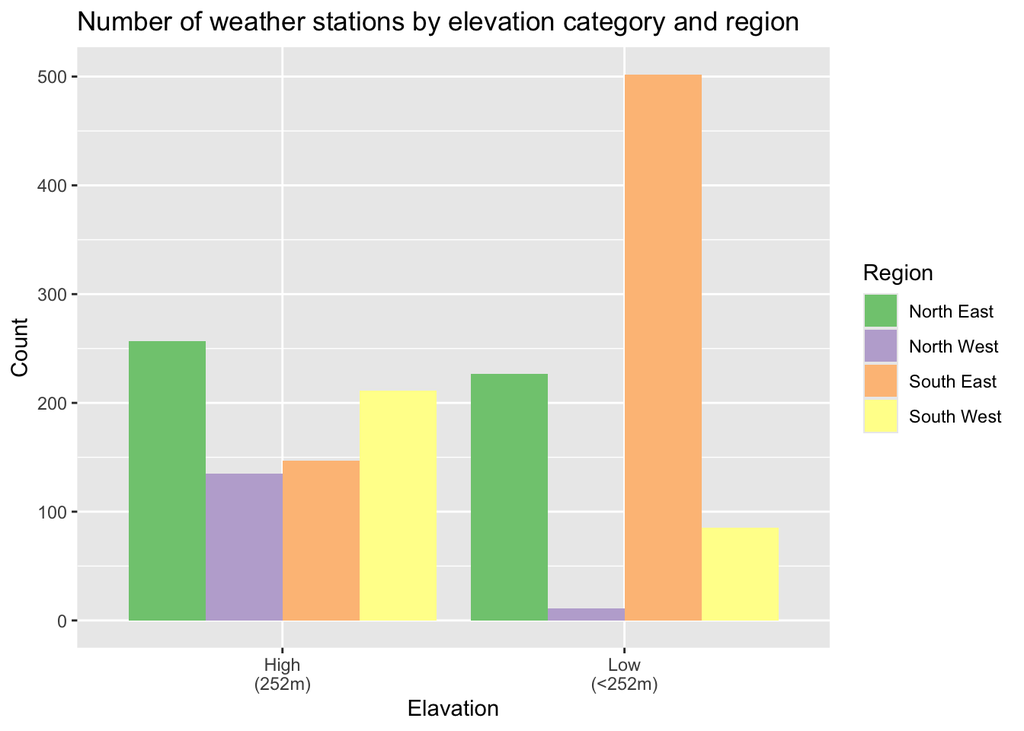

```r
met_avg |>
  filter(!is.na(region), !is.na(elev_cat)) |>
  ggplot() +
  geom_bar(mapping = aes(x = elev_cat, fill=region), position = "dodge") +
  scale_fill_brewer(palette = "Accent") +
  scale_x_discrete(labels=c("High\n(252m)", "Low\n(<252m)")) +
  labs(
    title="Number of weather stations by elevation category and region",
    x="Elavation",
    y="Count",
    fill="Region"
  )
```

### 6. Use `stat_summary` to examine mean dew point and wind speed by region with standard deviation error bars.

- Make sure to remove `NA`
- Use fun.data=“mean_sdl” in `stat_summary`
- Add another layer of `stats_summary` but change the geom to `"errorbar"` (see the help).
- Describe the graph and what you observe

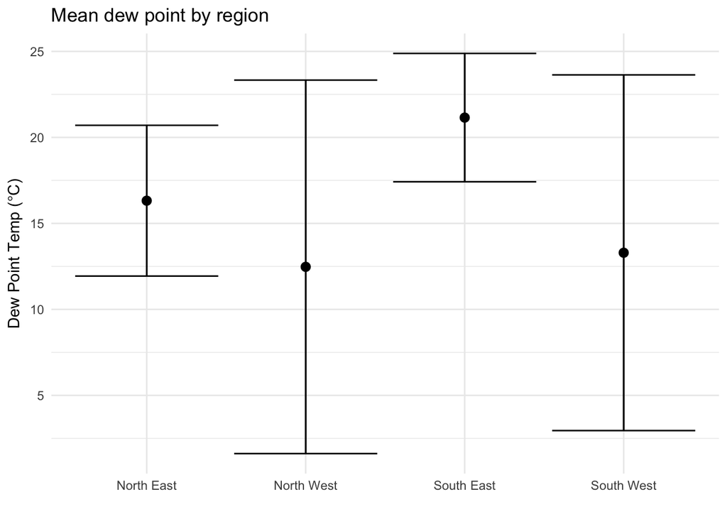

```r
met_avg |>
  filter(!is.na(region), !is.na(elev_cat)) |>
  ggplot(mapping = aes(x = region, y = dew.point)) +
  stat_summary(fun.data="mean_sdl") +
  stat_summary(fun.data="mean_sdl", geom="errorbar") +
  labs(
    x = "",
    y=expression("Dew Point Temp ("*degree*C*")"),
    title="Mean dew point by region"
    ) +
  theme_minimal()
```

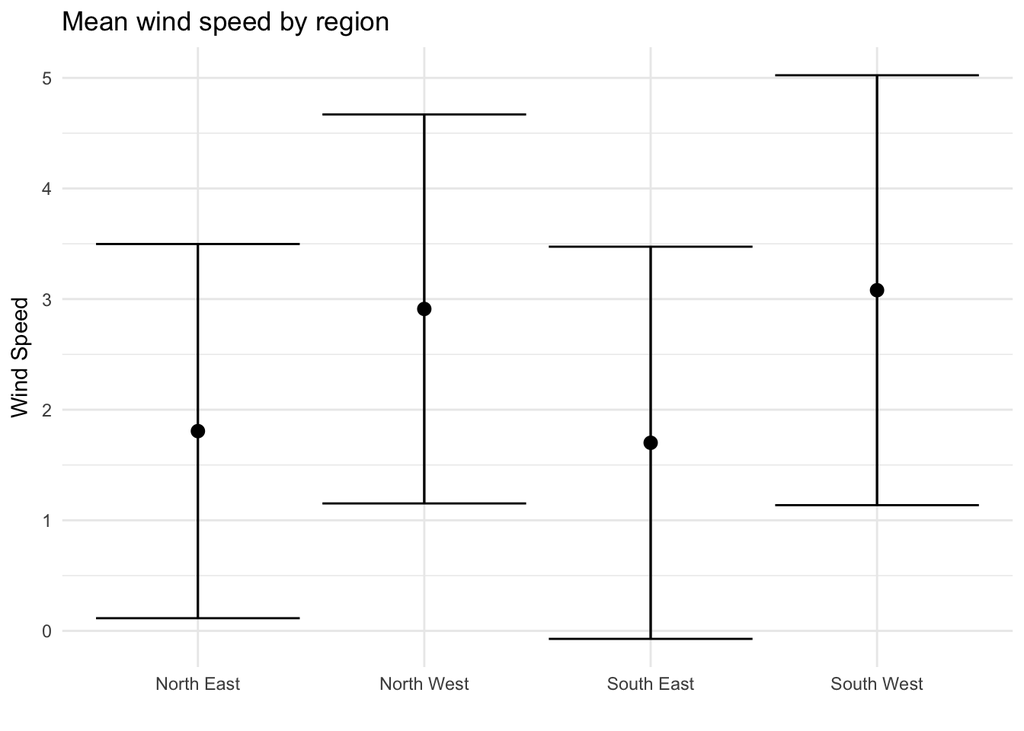

```r
met_avg |>
  filter(!is.na(region), !is.na(wind.sp)) |>
  ggplot(mapping = aes(x = region, y = wind.sp)) +
  stat_summary(fun.data="mean_sdl") +
  stat_summary(fun.data="mean_sdl", geom="errorbar") +
  labs(
    x = "",
    y=expression("Wind Speed"),
    title="Mean wind speed by region"
    ) +
  theme_minimal()
```

- Dew point temperature is around 10 to 25 degree celcius.
- Wind speed is around 1.5 to 4.

### 7. Make a map showing the spatial trend in relative humidity (`rh`) in the US

- Make sure to remove `NA`
- Use `leaflet()`
- Make a colour palette with custom colours
- Use `addMarkers` to include the top 10 places in relative h (hint: this will be useful `rank(-rh) <= 10`)
- Add a legend
- Describe trend in RH across the US

```r
met_avg2 <- met_avg[!is.na(rh)]
top10 <- met_avg2[rank(-rh) <= 10]

rh_pal <- colorNumeric(
  viridisLite::viridis(5, direction = -1),
  domain = met_avg2$rh
)
```

```r
leaflet(met_avg2) %>%
  addProviderTiles('OpenStreetMap') |>
  addCircles(lat = ~lat, lng = ~lon, color=~rh_pal(rh),
             label = ~paste0(round(rh, 2), ' rh'),
            opacity = 1, fillOpacity = 1, radius = 250) |>
  addMarkers(lat = ~lat, lng = ~lon,
             label = ~paste0(round(rh, 2), ' rh'),
             data=top10) |>
  addLegend('bottomleft', pal = rh_pal, values=met_avg2$rh,
            title="Relative Humidity (%)", opacity=1)
```

[interactive chart not shown]

### 8. Use a ggplot extension

- Pick and extension (except cowplot) from [here](https://exts.ggplot2.tidyverse.org/gallery/) and make a plot of your choice using the `met` data (or `met_avg`)
- Might want to try examples that come with the extension first (e.g. `ggtech`, `gganimate`, `ggforce`)

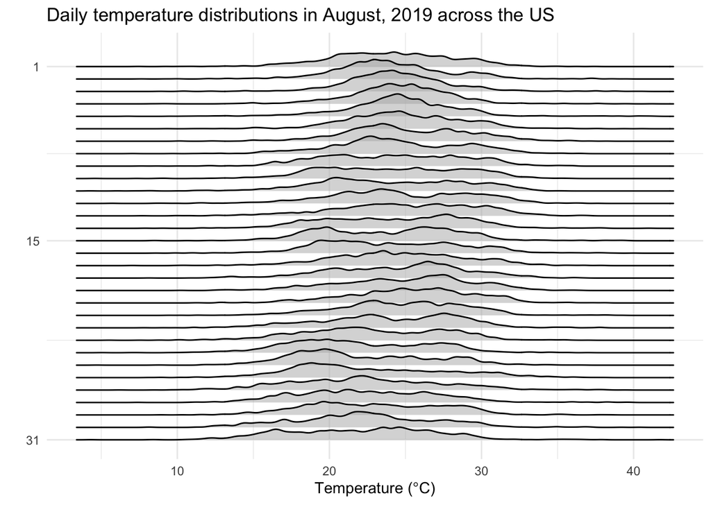

```r
library(ggridges)
met |>
  group_by(USAFID, day) |>
  summarise(temp = mean(temp, na.rm=TRUE), .groups="drop") |>
  ggplot() +
  theme_minimal() +
  geom_density_ridges(
    aes(x = temp, y = day, group = day),
    alpha = .5, bandwidth = .3
  ) +
  scale_y_reverse(breaks=c(1, 15, 31)) +
  labs(x = expression("Temperature ("*degree*C*")"), y="",
       title = "Daily temperature distributions in August, 2019 across the US")
```